# Week 2 Lab. Descriptive Statistics

Craig Enders

Friday October 9

■ data frame name ■ numeric variable ■ categorical variable (factor) ■ raw data file name

# The Data

The data for this lab come from a randomized clinical trial of pharmacological treatments for co-occurring cigarette smoking and heavy drinking. Medications that can address both behaviors at once stand to improve health care delivery for these highly prevalent co-occurring conditions. This superiority trial compared the combination of varenicline and naltrexone against varenicline alone for smoking cessation and drinking reduction among 165 heavy-drinking smokers (Ray, Green, Enders, et al., 2021, *American Journal of Psychiatry*, 178, 818–828).

Participants were randomly assigned to one of two medication arms: varenicline plus naltrexone, or varenicline plus placebo pills. Smoking and drinking were assessed at baseline (week 0) and again at weeks 4 and 8. Two variables are of primary interest.

**Breath carbon monoxide.** Breath (alveolar) carbon monoxide is a measure of carbon monoxide in the lungs. CO levels rise with tobacco inhalation and fall after abstinence, so breath CO is a biomarker of recent smoking behavior that is common in clinical trials. Higher values reflect more frequent smoking.

**Medication arm.** The treatment condition each participant was randomly assigned to.

[output not shown]

Notice that the categorical variables are entered as numbers, not labels: `Condition`, `Male`, and the two quit-status variables are all coded 0 and 1. In the raw file there is nothing to tell R that these codes are categories rather than quantities, which is why the labels in the table above matter. A later step uses the `factor()` function to attach those labels to the data.

# Preliminaries: Loading Packages

R’s built-in functions handle basic statistics, but the displays in this lab come from three add-on packages. `library()` makes a package’s functions available for the current session; it has to be run each time you open R, and it assumes the package was installed beforehand (see the Week 0 R Package Installation Script).

```r
# ggplot2 produces the histograms and density plots
library(ggplot2)

# psych provides describe() and describeBy() for descriptive statistics
library(psych)

# summarytools provides dfSummary() for data summaries
library(summarytools)

# rstudioapi talks to RStudio, used here to find the folder that contains this script
library(rstudioapi)
```

# Importing Data

There are two ways to get the data file into R. The document uses the first; the second is shown for reference because it is the one you will use with data files stored on your own computer.

Both methods call `read.csv()` with `stringsAsFactors = TRUE`, the same call used in the assignments. The argument converts any text column to a factor, but this file has none: the categorical variables `Condition`, `Male`, `QuitCigsWeek4`, and `QuitCigsWeek8` are stored as 0/1 codes, so every column, including these, is read as numeric. R will happily compute a mean of `Condition` unless told otherwise. The next section converts those codes to factors by hand.

## Option 1: Read From the Course Website

The data file lives on the course GitHub site. Store the web address in an object, then hand that address to `read.csv()`. Keeping the address in its own object is a small convenience: if the file moves, only one line changes.

```r
# store the web address of the raw data file
filepath <- "https://raw.githubusercontent.com/craigenders/psych250a/main/data/ClinicalTrial.csv"

# read the file at that address into a data frame named ClinicalTrial
ClinicalTrial <- read.csv(filepath, stringsAsFactors = TRUE)
```

## Option 2: Read From the Folder That Contains the Script

When a data file is saved in the same folder as your R script, you can point R at that folder and then refer to the file by name alone. The rstudioapi package asks RStudio for the path of the script you are currently editing; `dirname()` strips the file name to leave the folder, and `setwd()` makes that folder R’s working directory. `getwd()` prints the working directory so you can confirm it landed where you expected. After that, `read.csv()` needs only the file name.

This block is displayed but not run, because a knitted document has no script to locate. Run it from an R script saved next to `ClinicalTrial.csv`. In the lab script the same lines are commented out; remove the leading `#` to use them.

```r
# set the working directory to the folder that contains this script
setwd(dirname(getActiveDocumentContext()$path))

# print the working directory to confirm the location
getwd()

# read ClinicalTrial.csv from the working directory into a data frame named ClinicalTrial
ClinicalTrial <- read.csv("ClinicalTrial.csv", stringsAsFactors = TRUE)
```

# Converting Categorical Variables to Factors

R does not know that `Condition`, `Male`, `QuitCigsWeek4`, and `QuitCigsWeek8` are categorical; it sees four numeric columns of 0s and 1s. Left that way, plotting and summary functions would treat them as continuous variables. The `factor()` function converts a numeric column to a *factor*, R’s term for a categorical variable. The `levels` argument lists the codes in the data, and the `labels` argument gives each code a name; the two are matched in order, so 0 becomes the first label and 1 the second.

The conversion replaces each column in place. Once a column is a factor, re-running `factor()` on it with the same `levels` would produce all `NA` values, because the codes no longer exist, so run this block only once after reading the data.

```r
# convert Condition from 0/1 codes to a factor with descriptive labels
ClinicalTrial$Condition <- factor(ClinicalTrial$Condition,
                                  levels = c(0, 1),
                                  labels = c("Varenicline", "Varenicline + Naltrexone"))

# convert Male from 0/1 codes to a factor with descriptive labels
ClinicalTrial$Male <- factor(ClinicalTrial$Male,
                             levels = c(0, 1),
                             labels = c("Female", "Male"))

# convert QuitCigsWeek4 from 0/1 codes to a factor with descriptive labels
ClinicalTrial$QuitCigsWeek4 <- factor(ClinicalTrial$QuitCigsWeek4,
                                      levels = c(0, 1),
                                      labels = c("No Quit", "Quit"))

# convert QuitCigsWeek8 from 0/1 codes to a factor with descriptive labels
ClinicalTrial$QuitCigsWeek8 <- factor(ClinicalTrial$QuitCigsWeek8,
                                      levels = c(0, 1),
                                      labels = c("No Quit", "Quit"))

# print the first few rows to confirm the labels replaced the codes
head(ClinicalTrial)
```

```
  ID                Condition   Male COWeek0 COWeek4 COWeek8 QuitCigsWeek4 QuitCigsWeek8
1  1 Varenicline + Naltrexone   Male      12       2       3          Quit          Quit
2  2              Varenicline Female      20       0       1          Quit          Quit
3  3 Varenicline + Naltrexone   Male      19       3       1          Quit          Quit
4  4 Varenicline + Naltrexone Female       7       3       4          Quit          Quit
5  5 Varenicline + Naltrexone Female       6       7       0       No Quit          Quit
6  6 Varenicline + Naltrexone   Male      14       5       5          Quit          Quit
  DrinksWeek0 DrinksWeek4 DrinksWeek8 CigsWeek0 CigsWeek4 CigsWeek8
1           3           1           6        16         7         0
2           8           3           3        10         3         0
3           9           8           6         8         0         4
4           9           8           5        11         2         0
5           3           3           0         6         1         3
6           7           0           1        13         7         1
```

# Summarizing Data

Before computing anything, look at the whole data frame at once. `dfSummary()` from the summarytools package produces one row per variable showing its type, a compact summary of its values, a small graph of its distribution, and the number of valid and missing cases. It is the fastest way to confirm that a file read in correctly and to notice anything odd — a variable stored as the wrong type, an impossible value, unexpected missingness — before it contaminates later analyses. In the HTML version of this lab, the table is handed to `print()` with `method = "render"` so that it displays as formatted HTML; that wrapper is not needed in your own documents.

```r
# overview of every variable in the data frame
print(dfSummary(ClinicalTrial), method = "render")
```

Data Frame Summary

ClinicalTrial

**Dimensions**: 165 x 14  
**Duplicates**: 0

| **No** | **Variable** | **Stats / Values** | **Freqs (% of Valid)** | **Graph** | **Valid** | **Missing** |
| --- | --- | --- | --- | --- | --- | --- |
| 1 | ID [integer] | Mean (sd) : 83 (47.8) min ≤ med ≤ max: 1 ≤ 83 ≤ 165 IQR (CV) : 82 (0.6) | 165 distinct values (Integer sequence) |  | 165 (100.0%) | 0 (0.0%) |
| 2 | Condition [factor] | 1. Varenicline 2. Varenicline + Naltrexone | 82 ( 49.7% ) 83 ( 50.3% ) |  | 165 (100.0%) | 0 (0.0%) |
| 3 | Male [factor] | 1. Female 2. Male | 65 ( 39.4% ) 100 ( 60.6% ) |  | 165 (100.0%) | 0 (0.0%) |
| 4 | COWeek0 [integer] | Mean (sd) : 10.6 (6.9) min ≤ med ≤ max: 0 ≤ 9 ≤ 46 IQR (CV) : 8 (0.7) | 30 distinct values |  | 165 (100.0%) | 0 (0.0%) |
| 5 | COWeek4 [integer] | Mean (sd) : 5.5 (5.1) min ≤ med ≤ max: 0 ≤ 4 ≤ 24 IQR (CV) : 6 (0.9) | 21 distinct values |  | 165 (100.0%) | 0 (0.0%) |
| 6 | COWeek8 [integer] | Mean (sd) : 5.5 (6) min ≤ med ≤ max: 0 ≤ 3 ≤ 29 IQR (CV) : 8 (1.1) | 25 distinct values |  | 165 (100.0%) | 0 (0.0%) |
| 7 | QuitCigsWeek4 [factor] | 1. No Quit 2. Quit | 63 ( 38.2% ) 102 ( 61.8% ) |  | 165 (100.0%) | 0 (0.0%) |
| 8 | QuitCigsWeek8 [factor] | 1. No Quit 2. Quit | 59 ( 35.8% ) 106 ( 64.2% ) |  | 165 (100.0%) | 0 (0.0%) |
| 9 | DrinksWeek0 [integer] | Mean (sd) : 6.4 (4.4) min ≤ med ≤ max: 1 ≤ 6 ≤ 35 IQR (CV) : 4 (0.7) | 20 distinct values |  | 165 (100.0%) | 0 (0.0%) |
| 10 | DrinksWeek4 [integer] | Mean (sd) : 3.6 (3) min ≤ med ≤ max: 0 ≤ 3 ≤ 13 IQR (CV) : 4 (0.8) | 14 distinct values |  | 165 (100.0%) | 0 (0.0%) |
| 11 | DrinksWeek8 [integer] | Mean (sd) : 3.2 (2.7) min ≤ med ≤ max: 0 ≤ 3 ≤ 13 IQR (CV) : 4 (0.8) | 14 distinct values |  | 165 (100.0%) | 0 (0.0%) |
| 12 | CigsWeek0 [integer] | Mean (sd) : 14.2 (8.2) min ≤ med ≤ max: 3 ≤ 12 ≤ 51 IQR (CV) : 10 (0.6) | 33 distinct values |  | 165 (100.0%) | 0 (0.0%) |
| 13 | CigsWeek4 [integer] | Mean (sd) : 4.2 (5.7) min ≤ med ≤ max: 0 ≤ 2 ≤ 41 IQR (CV) : 5 (1.4) | 22 distinct values |  | 165 (100.0%) | 0 (0.0%) |
| 14 | CigsWeek8 [integer] | Mean (sd) : 3.2 (4.8) min ≤ med ≤ max: 0 ≤ 2 ≤ 35 IQR (CV) : 4 (1.5) | 18 distinct values |  | 165 (100.0%) | 0 (0.0%) |

Generated by summarytools 1.1.5 ([R](https://www.r-project.org/) version 4.6.1)  
2026-10-16

## Summarizing a Subset of Variables

A data frame with many columns produces a long table. Square brackets select part of a data frame: the general form is `ClinicalTrial[rows, columns]`. An empty `rows` position keeps every row, and `c("Condition", "COWeek8")` in the `columns` position keeps only the two named columns. The result is a smaller data frame that `dfSummary()` summarizes in the usual way.

```r
# overview of just Condition and COWeek8
print(dfSummary(ClinicalTrial[, c("Condition", "COWeek8")]), method = "render")
```

Data Frame Summary

ClinicalTrial

**Dimensions**: 165 x 2  
**Duplicates**: 125

| **No** | **Variable** | **Stats / Values** | **Freqs (% of Valid)** | **Graph** | **Valid** | **Missing** |
| --- | --- | --- | --- | --- | --- | --- |
| 1 | Condition [factor] | 1. Varenicline 2. Varenicline + Naltrexone | 82 ( 49.7% ) 83 ( 50.3% ) |  | 165 (100.0%) | 0 (0.0%) |
| 2 | COWeek8 [integer] | Mean (sd) : 5.5 (6) min ≤ med ≤ max: 0 ≤ 3 ≤ 29 IQR (CV) : 8 (1.1) | 25 distinct values |  | 165 (100.0%) | 0 (0.0%) |

Generated by summarytools 1.1.5 ([R](https://www.r-project.org/) version 4.6.1)  
2026-10-16

# Descriptive Statistics

`describe()` from the psych package computes the standard numeric summaries for every variable in a data frame: sample size, mean, standard deviation, median, trimmed mean, median absolute deviation, minimum, maximum, range, skewness, kurtosis, and the standard error of the mean.

The `kurtosis` column reports *excess* kurtosis, not raw kurtosis. Raw kurtosis equals 3 for a normal distribution; `describe()` subtracts that 3, so a value of 0 indicates normal tail weight, positive values indicate heavier tails than the normal curve, and negative values indicate lighter tails.

```r
# descriptive statistics for every variable in the data frame
describe(ClinicalTrial)
```

```
               vars   n  mean    sd median trimmed   mad min max range  skew kurtosis   se
ID                1 165 83.00 47.78     83   83.00 60.79   1 165   164  0.00    -1.22 3.72
Condition*        2 165  1.50  0.50      2    1.50  0.00   1   2     1 -0.01    -2.01 0.04
Male*             3 165  1.61  0.49      2    1.63  0.00   1   2     1 -0.43    -1.83 0.04
COWeek0           4 165 10.55  6.86      9    9.82  5.93   0  46    46  1.41     3.60 0.53
COWeek4           5 165  5.46  5.10      4    4.69  4.45   0  24    24  1.24     0.96 0.40
COWeek8           6 165  5.53  5.96      3    4.55  2.97   0  29    29  1.75     3.35 0.46
QuitCigsWeek4*    7 165  1.62  0.49      2    1.65  0.00   1   2     1 -0.48    -1.78 0.04
QuitCigsWeek8*    8 165  1.64  0.48      2    1.68  0.00   1   2     1 -0.59    -1.66 0.04
DrinksWeek0       9 165  6.40  4.42      6    5.77  2.97   1  35    34  2.44    10.46 0.34
DrinksWeek4      10 165  3.59  2.98      3    3.30  2.97   0  13    13  0.80     0.30 0.23
DrinksWeek8      11 165  3.23  2.68      3    2.97  2.97   0  13    13  0.89     0.67 0.21
CigsWeek0        12 165 14.22  8.22     12   13.05  5.93   3  51    48  1.59     3.20 0.64
CigsWeek4        13 165  4.18  5.70      2    3.08  2.97   0  41    41  3.01    13.13 0.44
CigsWeek8        14 165  3.16  4.75      2    2.25  2.97   0  35    35  3.44    16.81 0.37
```

Compare the mean and median for `COWeek8`. The mean sits well above the median, and the skewness is strongly positive: most participants have low CO readings at week 8, and a smaller number of high readings in the upper tail pull the mean upward. The median is unaffected by those extreme values, which is why the two measures of center disagree.

# Distribution Plots by Group

To compare the medication arms, draw the same histogram-plus-density display separately for each level of `Condition`. Every ggplot2 graph is built in layers joined by `+`:

- `ggplot(ClinicalTrial, aes(x = COWeek8, colour = Condition))` names the data frame, maps `COWeek8` to the horizontal axis, and maps the grouping variable to the outline color of the bars and curve, so each group is drawn in its own color and a legend is added automatically.
- `geom_histogram()` adds the bars. Inside it, `aes(y = after_stat(density))` changes the vertical axis from raw counts to density — the proportion of cases per unit of the horizontal axis. This rescaling is what allows a density curve to be drawn on the same axes.
- `geom_density()` adds the smoothed curve.
- `facet_wrap(~ Condition)` splits the display into one panel per level of `Condition`, placed side by side on identical axes. Identical axes are what make the panels comparable — a shift in location or a difference in spread is visible directly.

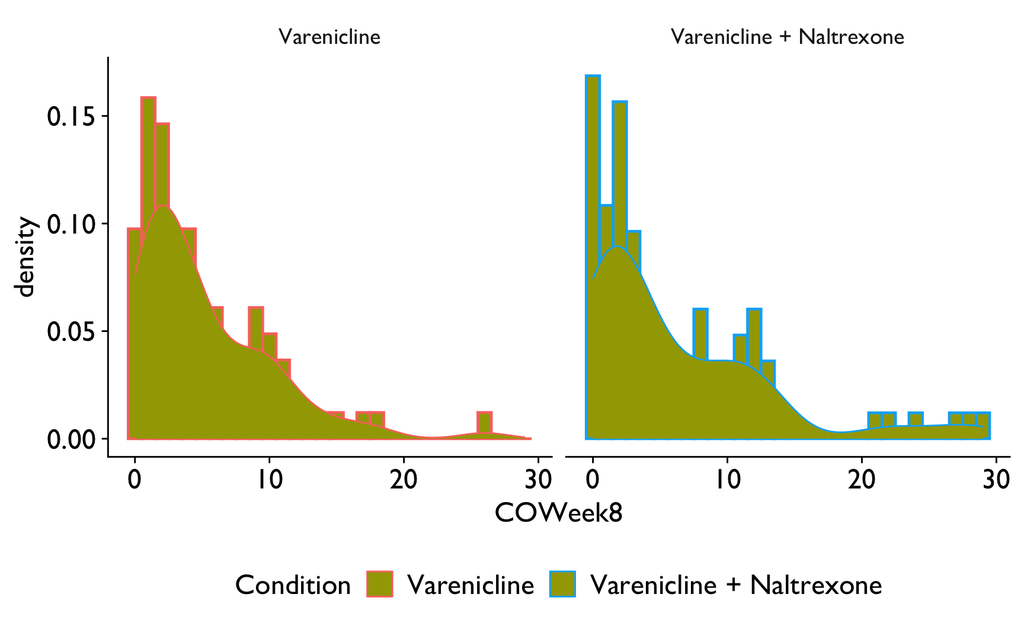

```r
# histogram with density curve for COWeek8, one panel per Condition group
ggplot(ClinicalTrial, aes(x = COWeek8, colour = Condition)) +
  geom_histogram(aes(y = after_stat(density))) +
  geom_density() +
  facet_wrap(~ Condition)
```

# Descriptive Statistics by Group

`describeBy()` from the psych package computes the same statistics as `describe()` separately for each level of a grouping variable. It can be called in two ways: with a formula that summarizes one variable, or with the `group` argument that summarizes every variable in the data frame.

The formula `COWeek8 ~ Condition` reads “COWeek8 broken down by Condition”: the variable to summarize goes on the left of the tilde and the grouping variable on the right. The `data` argument names the data frame that contains both.

```r
# descriptive statistics for COWeek8 within each Condition group
describeBy(COWeek8 ~ Condition, data = ClinicalTrial)
```

```
 Descriptive statistics by group
Condition: Varenicline
        vars  n mean   sd median trimmed  mad min max range skew kurtosis   se
COWeek8    1 82 5.02 4.88    3.5    4.33 3.71   0  26    26 1.57     3.09 0.54
---------------------------------------------------------------------------
Condition: Varenicline + Naltrexone
        vars  n mean   sd median trimmed  mad min max range skew kurtosis   se
COWeek8    1 83 6.02 6.86      3    4.81 4.45   0  29    29 1.62     2.31 0.75
```

The combination arm has the lower median but the higher mean, so its larger mean comes from its upper tail rather than from a shift in the bulk of the distribution. The standard deviations also differ, with the combination arm showing more spread.

```r
# descriptive statistics for every variable within each Condition group
describeBy(ClinicalTrial, group = ClinicalTrial$Condition)
```

```
 Descriptive statistics by group
group: Varenicline
              vars  n  mean    sd median trimmed   mad min max range  skew kurtosis   se
ID               1 82 88.39 44.10   91.5   89.36 50.41   2 163   161 -0.13    -0.99 4.87
Condition        2 82  1.00  0.00    1.0    1.00  0.00   1   1     0   NaN      NaN 0.00
Male             3 82  1.63  0.48    2.0    1.67  0.00   1   2     1 -0.55    -1.72 0.05
COWeek0          4 82  9.46  7.42    8.0    8.35  4.45   0  46    46  2.01     5.98 0.82
COWeek4          5 82  5.48  5.30    4.0    4.74  4.45   0  19    19  0.97    -0.12 0.59
COWeek8          6 82  5.02  4.88    3.5    4.33  3.71   0  26    26  1.57     3.09 0.54
QuitCigsWeek4    7 82  1.61  0.49    2.0    1.64  0.00   1   2     1 -0.44    -1.83 0.05
QuitCigsWeek8    8 82  1.66  0.48    2.0    1.70  0.00   1   2     1 -0.66    -1.59 0.05
DrinksWeek0      9 82  6.43  3.95    6.0    5.92  2.97   1  21    20  1.24     1.79 0.44
DrinksWeek4     10 82  3.79  3.20    3.0    3.42  2.97   0  13    13  0.94     0.48 0.35
DrinksWeek8     11 82  3.55  2.82    3.0    3.26  2.97   0  13    13  1.01     0.93 0.31
CigsWeek0       12 82 14.11  7.91   11.5   13.09  6.67   4  51    47  1.74     4.66 0.87
CigsWeek4       13 82  4.51  5.77    2.0    3.45  2.97   0  33    33  2.15     6.08 0.64
CigsWeek8       14 82  3.43  5.08    2.0    2.44  2.97   0  35    35  3.50    16.80 0.56
---------------------------------------------------------------------------
group: Varenicline + Naltrexone
              vars  n  mean    sd median trimmed   mad min max range  skew kurtosis   se
ID               1 83 77.67 50.85     74   76.61 66.72   1 165   164  0.16    -1.38 5.58
Condition        2 83  2.00  0.00      2    2.00  0.00   2   2     0   NaN      NaN 0.00
Male             3 83  1.58  0.50      2    1.60  0.00   1   2     1 -0.31    -1.93 0.05
COWeek0          4 83 11.63  6.12     11   11.19  7.41   0  30    30  0.67     0.17 0.67
COWeek4          5 83  5.45  4.94      4    4.63  2.97   0  24    24  1.54     2.21 0.54
COWeek8          6 83  6.02  6.86      3    4.81  4.45   0  29    29  1.62     2.31 0.75
QuitCigsWeek4    7 83  1.63  0.49      2    1.66  0.00   1   2     1 -0.51    -1.76 0.05
QuitCigsWeek8    8 83  1.63  0.49      2    1.66  0.00   1   2     1 -0.51    -1.76 0.05
DrinksWeek0      9 83  6.37  4.87      5    5.61  2.97   1  35    34  2.98    13.19 0.53
DrinksWeek4     10 83  3.40  2.76      3    3.18  2.97   0  11    11  0.50    -0.57 0.30
DrinksWeek8     11 83  2.92  2.52      2    2.70  2.97   0  11    11  0.64    -0.28 0.28
CigsWeek0       12 83 14.33  8.56     12   13.00  5.93   3  42    39  1.43     1.95 0.94
CigsWeek4       13 83  3.84  5.64      2    2.79  2.97   0  41    41  3.88    20.91 0.62
CigsWeek8       14 83  2.89  4.42      1    2.06  1.48   0  30    30  3.18    14.93 0.49
```

# Standardizing Variables as z-Scores

A z-score expresses a score as its distance from the mean in standard deviation units: z = (score − mean) / SD. A z-score of 0 is exactly average, +1 is one standard deviation above the mean, and −1 is one standard deviation below. Standardizing puts variables with different scales on a common footing and makes a mean difference between groups directly readable as a fraction of a standard deviation.

`scale()` in base R does the conversion. It returns a one-column matrix, and assigning the result to `ClinicalTrial$zCOWeek8` adds it to the data frame as a new variable; the original `COWeek8` column is left unchanged.

```r
# convert COWeek8 to z-scores and store them as a new variable zCOWeek8
ClinicalTrial$zCOWeek8 <- scale(ClinicalTrial$COWeek8)
```

The square-bracket selection used earlier limits `describe()` to the original and standardized versions of the variable so the two can be compared side by side.

```r
# descriptive statistics for COWeek8 and its z-score version
describe(ClinicalTrial[, c("COWeek8", "zCOWeek8")])
```

```
         vars   n mean   sd median trimmed  mad   min   max range skew kurtosis   se
COWeek8     1 165 5.53 5.96   3.00    4.55 2.97  0.00 29.00 29.00 1.75     3.35 0.46
zCOWeek8    2 165 0.00 1.00  -0.42   -0.16 0.50 -0.93  3.94  4.87 1.75     3.35 0.08
```

Standardizing changes the mean to 0 and the standard deviation to 1 but leaves the shape of the distribution alone: the skewness and kurtosis of `zCOWeek8` are identical to those of `COWeek8`. A z-score is a relabeling of the axis, not a transformation of the shape.

```r
# descriptive statistics for zCOWeek8 within each Condition group
describeBy(zCOWeek8 ~ Condition, data = ClinicalTrial)
```

```
 Descriptive statistics by group
Condition: Varenicline
         vars  n  mean   sd median trimmed  mad   min  max range skew kurtosis   se
zCOWeek8    1 82 -0.08 0.82  -0.34    -0.2 0.62 -0.93 3.44  4.36 1.57     3.09 0.09
---------------------------------------------------------------------------
Condition: Varenicline + Naltrexone
         vars  n mean   sd median trimmed  mad   min  max range skew kurtosis   se
zCOWeek8    1 83 0.08 1.15  -0.42   -0.12 0.75 -0.93 3.94  4.87 1.62     2.31 0.13
```

Because the z-scores were computed using the full-sample mean and standard deviation, each group’s mean z-score is its distance from the overall mean in standard deviation units. The two group means are small and roughly symmetric around 0, which says the medication arms differ by only a modest fraction of a standard deviation on week 8 breath CO.